# Household Travel Survey: Vehicle Ownership

Mary Richards

December 02 2020

This report presents preliminary findings for household vehicle ownership trends based on the Household Travel Survey (2017 and 2019), a survey conducted every other year to determine travel patterns for individuals living within PSRC’s four-county jurisdiction. :blue_car: :red_car:

*Table of Contents*

Section

Description

1

**Background Information**

Variables

- Outcome variable
- Explanatory variables

2

**Univariate Analysis**

3

**Correlation Matrix**

## 1. Background Information

This section describes the different explanatory and outcome variables.

## 2. Outcome Variables

The two outcome variables from these models are at the household level (by household id):  
1) Vehicle count - the number of vehicles owned reported by survey respondents  
2) Vehicle access - the number of household vehicles owned in relation to the number of workers in each household

### a.Household Vehicle Count

Survey Responses:  
*“How many motor vehicles (in working order) are there in your household?”*

|  | Overall (N=11940) |
| --- | --- |
| vehcount_ordered |  |
| 0 (no vehicles) | 1473 (12%) |
| 1 | 4855 (41%) |
| 2 | 4239 (36%) |
| 3 | 967 (8%) |
| 4 | 282 (2%) |
| 5 | 96 (1%) |
| 6 | 13 (0%) |
| 7 | 4 (0%) |
| 8 | 2 (0%) |
| 9 | 4 (0%) |
| 10 or more vehicles | 5 (0%) |

```
## # A tibble: 11 x 5
##    vehcount_ordered        n sum_wt_comb perc_comb   MOE
##    <fct>               <int>       <dbl>     <dbl> <dbl>
##  1 0 (no vehicles)      1473      188981      4.66  0.76
##  2 1                    4855      824217     20.3   0.76
##  3 2                    4239     1780958     44.0   0.76
##  4 3                     967      863051     21.3   0.76
##  5 4                     282      218840      5.4   0.76
##  6 5                      96      129653      3.2   0.76
##  7 6                      13       23940      0.59  0.76
##  8 7                       4        5252      0.13  0.76
##  9 8                       2         596      0.01  0.76
## 10 9                       4        1541      0.04  0.76
## 11 10 or more vehicles     5       14551      0.36  0.76
```

Based on survey responses, there is a very small number of households with more than 3 vehicles, so these households are grouped together.

|  | Overall (N=11940) |
| --- | --- |
| vehicle_group |  |
| 0 | 1473 (12%) |
| 1 | 4855 (41%) |
| 2 | 4239 (36%) |
| 3 | 1373 (11%) |

```
## # A tibble: 4 x 5
##   vehicle_group     n sum_wt_comb perc_comb   MOE
##   <fct>         <int>       <dbl>     <dbl> <dbl>
## 1 0              1473      188981      4.66  0.76
## 2 1              4855      824217     20.3   0.76
## 3 2              4239     1780958     44.0   0.76
## 4 3              1373     1257424     31.0   0.76
```

### b. Household Vehicle Access

This variable is based on the number of household vehicles (explained above) and the number of workers within the household.

|  | Overall (N=11940) |
| --- | --- |
| numworkers |  |
| 0 | 1727 (14%) |
| 1 | 4578 (38%) |
| 2 | 5052 (42%) |
| 3 | 472 (4%) |
| 4 | 87 (1%) |
| 5 | 24 (0%) |

```
## # A tibble: 6 x 5
##   numworkers     n sum_wt_comb perc_comb   MOE
##   <fct>      <int>       <dbl>     <dbl> <dbl>
## 1 0           1727      558573     13.8   0.76
## 2 1           4578     1345825     33.2   0.76
## 3 2           5052     1637852     40.4   0.76
## 4 3            472      384489      9.49  0.76
## 5 4             87      102756      2.54  0.76
## 6 5             24       22086      0.55  0.76
```

Based on survey responses, there is a very small number of households with more than 3 workers, so these households are grouped together

|  | Overall (N=11940) |
| --- | --- |
| numworkers_group |  |
| 0 | 1727 (14%) |
| 1 | 4578 (38%) |
| 2 | 5052 (42%) |
| 3 | 583 (5%) |

```
## # A tibble: 4 x 5
##   numworkers_group     n sum_wt_comb perc_comb   MOE
##   <fct>            <int>       <dbl>     <dbl> <dbl>
## 1 0                 1727      558573      13.8  0.76
## 2 1                 4578     1345825      33.2  0.76
## 3 2                 5052     1637852      40.4  0.76
## 4 3                  583      509331      12.6  0.76
```

**Vehicle Access is calculated by comparing the number of vehicles and the number of workers per household**

- *limited access*: vehicles < workers
- *equal access*: vehicles = workers
- *good access*: vehicles > workers

|  | Overall (N=11940) |
| --- | --- |
| hh_veh_access |  |
| Reduced access | 8453 (71%) |
| Equal access | 2523 (21%) |
| Good access | 964 (8%) |

## 3. Explanatory or predictor variables

There are many personal and household characteristics that can contribute to vehicle ownership at the household level.

Based on these considerations and the data available through survey responses, the following table will attempt to match the person-level and household-level characteristics with responses provided by the survey participants. The data listed in the right column are from the in-house person (p) and household (h) views, available through Elmer, or describe an externally-sourced dataset (e).

Vehicle-ownership Considerations

Survey Variables

1. Income

*hhincome_broad (p), hhincome_detailed (h)*

2. Gender

*gender (p)*

3. Age

*age (p), age_category (p)*

4. Household size

*hhsize (p/h)*

5. Number of licensed (or licensed age) individuals

*license (p)*

6. Occupation

*employment (p), jobs_count (p)*

7. Educational Attainment

*education (p)*

8. Number of workers

*numworkers (h)*

9. Household lifecycle or age composition of household members

*lifecycle (p/h)*

10. Race or ethnicity

*race_category (p)*

11. Physical disabilities

*?*

12. Housing type

*rent_own (h), res_type (h)*

13. Housing or work location and proximity to transit

*final_home_rgcnum (h), seattle_home (h)*

14. Commuting patterns

*commute_freq (p), commute_mode (p), commute_dur (p), telecommute_freq (p)*

15. Quality of transit options available

*transit score by block group (e)*

16. Housing proximity to services

*displacement risk index (e)*

17. Environmental consciousness

*?*

### a. Univariate analysis

The dependent variable or outcome will be vehicle ownership (*“vehicle_group”*: 0, 1, 2, 3+) and the independent or explanatory variables will be from the list above. Because the vehicle ownership is ordinal, an ordered logit model will be applied.

The following section will introduce descriptive statistics for each of the explanatory variables, followed by analysis. For an overview of the results from these individual analyses, please skip to section 3b.

#### *1. Income*

The survey variable “hhincome_broad” is divided into 5 categories, while the survey variable “hhincome_detailed” is divided into 10 categories. Although the broader categories do not provide as much detail, the sample sizes within each category are larger and there are fewer households who chose “Prefer not to answer” (broad: 829, detailed: 1,309).

```
##
##        Under $25,000      $25,000-$49,999      $50,000-$74,999
##                  880                 1439                 1644
##      $75,000-$99,999     $100,000 or more Prefer not to answer
##                 1572                 5576                  829
```

| hhincomeb_reordered | Percentage_0 | Percentage_1 | Percentage_2 | Percentage_3 | Total_0 | Total_1 | Total_2 | Total_3 | Count_0 | Count_1 | Count_2 | Count_3 | sample_size | MOE_Percent |
| --- | --- | --- | --- | --- | --- | --- | --- | --- | --- | --- | --- | --- | --- | --- |
| $100,000 or more | 1.115487 | 9.46580 | 48.40909 | 41.009620 | 21201.444 | 179911.27 | 920085.11 | 779447.37 | 366 | 1946 | 2425 | 839 | 5576 | 1.101475 |
| $25,000-$49,999 | 9.567764 | 30.86043 | 43.15287 | 16.418929 | 46347.942 | 149493.39 | 209040.16 | 79536.20 | 316 | 736 | 310 | 77 | 1439 | 2.168231 |
| $50,000-$74,999 | 5.141395 | 33.71003 | 39.75223 | 21.396350 | 29223.200 | 191604.58 | 225947.87 | 121614.81 | 215 | 764 | 513 | 152 | 1644 | 2.028547 |
| $75,000-$99,999 | 2.240069 | 17.25652 | 47.35162 | 33.151793 | 11113.970 | 85617.21 | 234932.22 | 164480.64 | 135 | 683 | 572 | 182 | 1572 | 2.074482 |
| Prefer not to answer | 1.530416 | 18.13118 | 46.18174 | 34.156666 | 4322.803 | 51213.20 | 130444.60 | 96478.67 | 79 | 316 | 333 | 101 | 829 | 2.856661 |
| Under $25,000 | 24.026961 | 52.07048 | 18.93690 | 4.965661 | 76771.804 | 166377.45 | 60507.87 | 15866.46 | 362 | 410 | 86 | 22 | 880 | 2.772647 |

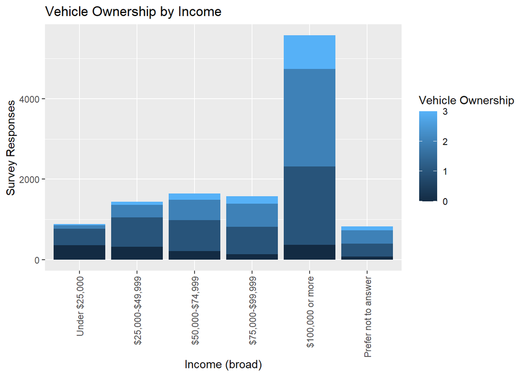

Reference group: Under $25,000

```
##                                      Value Std. Error  t value       p-value
## explanatory$25,000-$49,999       0.9383255 0.08196576 11.44777  2.412637e-30
## explanatory$50,000-$74,999       1.5693896 0.08081656 19.41916  5.315426e-84
## explanatory$75,000-$99,999       1.8985236 0.08164707 23.25281 1.332527e-119
## explanatory$100,000 or more      2.2784228 0.07213291 31.58645 5.666643e-219
## explanatoryPrefer not to answer  2.0123139 0.09320345 21.59055 2.203691e-103
## 0|1                             -0.3566020 0.06453166 -5.52600  3.276137e-08
## 1|2                              1.9480098 0.06844416 28.46130 3.531806e-178
## 2|3                              3.9661812 0.07345422 53.99528  0.000000e+00
##                                 simp p-value
## explanatory$25,000-$49,999                 0
## explanatory$50,000-$74,999                 0
## explanatory$75,000-$99,999                 0
## explanatory$100,000 or more                0
## explanatoryPrefer not to answer            0
## 0|1                                        0
## 1|2                                        0
## 2|3                                        0
```

**Vehicle Ownership by Income**

|  | *Dependent variable:* |
| --- | --- |
|  | outcome |
| 49,999 | 0.938*** |
|  | (0.082) |
| 74,999 | 1.569*** |
|  | (0.081) |
| 99,999 | 1.899*** |
|  | (0.082) |
| 100,000 or more | 2.278*** |
|  | (0.072) |
| explanatoryPrefer not to answer | 2.012*** |
|  | (0.093) |
| Observations | 11,940 |
| *Note:* | <sup>⋆</sup>p<0.1; <sup>⋆⋆</sup>p<0.05; <sup>⋆⋆⋆</sup>p<0.01 |

In reference to the households making under $25k, households in higher income categories are more likely to own more vehicles. This positive association between household income and household vehicle ownership is statistically significant.

#### *2. Gender*

```
##
##  Female    Male Another
##    5931    5734     275
```

| gender_simp | Percentage_0 | Percentage_1 | Percentage_2 | Percentage_3 | Total_0 | Total_1 | Total_2 | Total_3 | Count_0 | Count_1 | Count_2 | Count_3 | sample_size | MOE_Percent |
| --- | --- | --- | --- | --- | --- | --- | --- | --- | --- | --- | --- | --- | --- | --- |
| Another | 3.375138 | 18.21215 | 38.86411 | 39.54859 | 4487.23 | 24212.97 | 51669.65 | 52579.67 | 43 | 115 | 85 | 32 | 275 | 4.959862 |
| Female | 4.922338 | 22.17659 | 43.79769 | 29.10338 | 96861.97 | 436391.79 | 861852.72 | 572697.50 | 677 | 2518 | 2079 | 657 | 5931 | 1.068002 |
| Male | 4.492042 | 18.63888 | 44.46502 | 32.40406 | 87631.96 | 363612.33 | 867435.43 | 632146.99 | 753 | 2222 | 2075 | 684 | 5734 | 1.086193 |

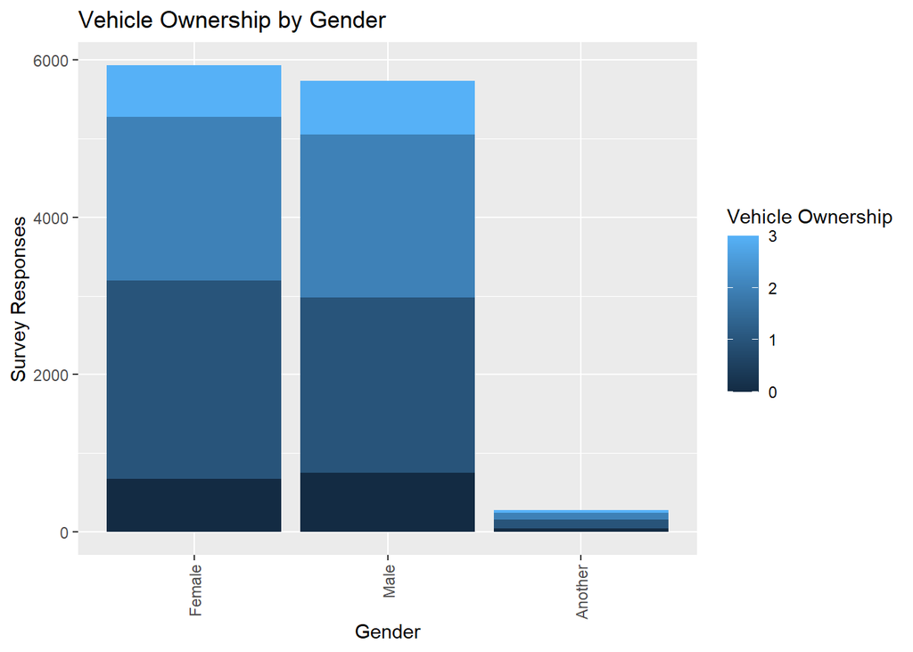

Reference group: Female

```
##                          Value Std. Error     t value      p-value simp p-value
## explanatoryMale     0.03409148 0.03410576   0.9995812 3.175132e-01       0.3175
## explanatoryAnother -0.16470583 0.11520233  -1.4297093 1.528005e-01       0.1528
## 0|1                -1.94886746 0.03243279 -60.0894091 0.000000e+00       0.0000
## 1|2                 0.13261309 0.02483618   5.3395130 9.319659e-08       0.0000
## 2|3                 2.05373511 0.03336293  61.5573961 0.000000e+00       0.0000
```

**Vehicle Ownership by Gender**

|  | *Dependent variable:* |
| --- | --- |
|  | outcome |
| explanatoryMale | 0.034 |
|  | (0.034) |
| explanatoryAnother | -0.165 |
|  | (0.115) |
| Observations | 11,940 |
| *Note:* | <sup>⋆</sup>p<0.1; <sup>⋆⋆</sup>p<0.05; <sup>⋆⋆⋆</sup>p<0.01 |

The relationship between gender and household vehicle ownership is not statistically significant.

#### *3. Age/Lifecycle*

Person-level ages are likely to influence vehicle ownership, but because the variable of interest is vehicle ownership, the household age composition or household lifecycle will be evaluated.

Households were organized into four categories based on the composition and age of people in the household:

- *Households with children:* any household with at least one member under age 18
- *Households with younger adults:* any household without children where all adults are age 18-34
- *Households with older adults:* any household without children where all adults are age 18-64 and at least one adult is age 35-64
- *Households with seniors:* any household with at one adult age 65 and older

```
##
##         Household includes children age 5-17
##                                         1780
##          Household includes children under 5
##                                         1906
##  Household size = 1, Householder age 35 - 64
##                                         1222
##      Household size = 1, Householder age 65+
##                                          525
## Household size = 1, Householder under age 35
##                                          863
##  Household size > 1, Householder age 35 - 64
##                                         2325
##      Household size > 1, Householder age 65+
##                                         1120
## Household size > 1, Householder under age 35
##                                         2199
```

Because of the large number of categories - accounting for both size and age, they are reduced to reflect only age ranges

```
##
##           Under age 35              Age 35-64                Age 65+
##                   3062                   3547                   1645
##  With children under 5 With children age 5-17
##                   1906                   1780
```

| hh_lifecycle | Percentage_0 | Percentage_1 | Percentage_2 | Percentage_3 | Total_0 | Total_1 | Total_2 | Total_3 | Count_0 | Count_1 | Count_2 | Count_3 | sample_size | MOE_Percent |
| --- | --- | --- | --- | --- | --- | --- | --- | --- | --- | --- | --- | --- | --- | --- |
| Age 35-64 | 8.1812183 | 24.54709 | 31.55997 | 35.71172 | 80119.070 | 240390.89 | 309068.3 | 349726.59 | 528 | 1537 | 1038 | 444 | 3547 | 1.381037 |
| Age 65+ | 4.1344878 | 25.35342 | 36.06335 | 34.44874 | 25258.343 | 154888.69 | 220317.6 | 210453.65 | 178 | 665 | 551 | 251 | 1645 | 2.027930 |
| Under age 35 | 13.0322024 | 38.60236 | 36.94478 | 11.42066 | 68641.127 | 203320.16 | 194589.6 | 60153.04 | 682 | 1601 | 669 | 110 | 3062 | 1.486392 |
| With children age 5-17 | 0.9019834 | 11.08524 | 49.30555 | 38.70724 | 10512.130 | 129192.44 | 574629.5 | 451111.95 | 46 | 439 | 926 | 369 | 1780 | 1.949512 |
| With children under 5 | 0.5785818 | 12.53563 | 62.70779 | 24.17801 | 4450.492 | 96424.92 | 482352.7 | 185978.92 | 39 | 613 | 1055 | 199 | 1906 | 1.883972 |

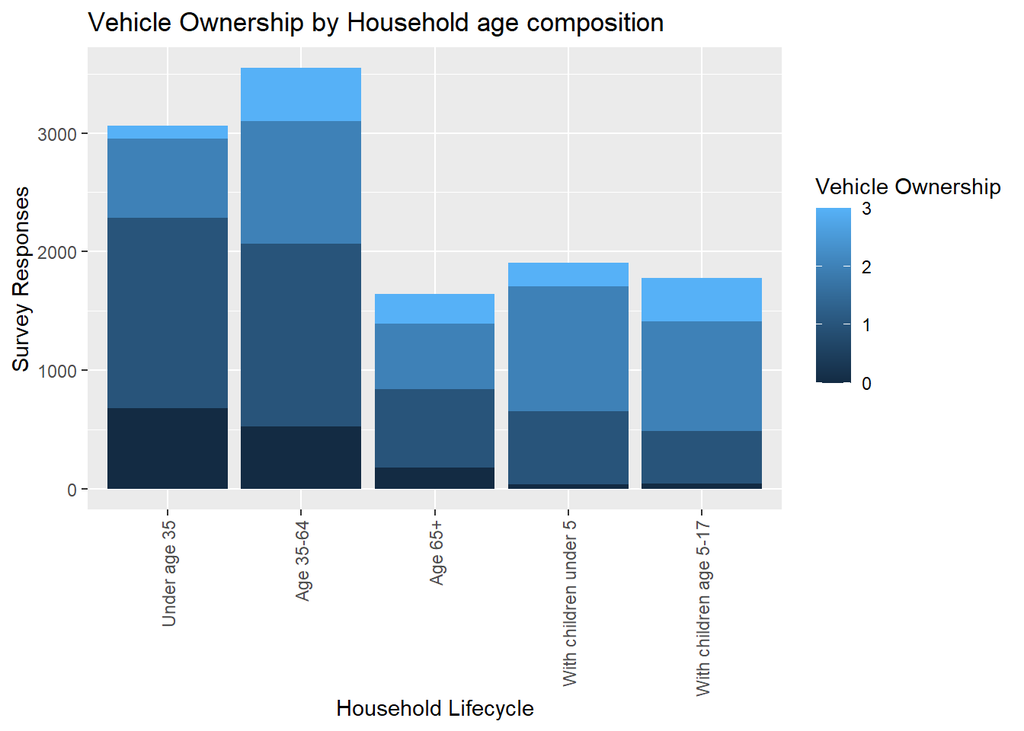

Reference group: Under age 35

```
##                                        Value Std. Error   t value       p-value
## explanatoryAge 35-64               0.7389568 0.04730411  15.62141  5.204376e-55
## explanatoryAge 65+                 1.0667969 0.05870226  18.17301  8.443272e-74
## explanatoryWith children under 5   1.5550875 0.05470503  28.42677 9.441518e-178
## explanatoryWith children age 5-17  1.9409713 0.05754317  33.73070 2.051688e-249
## 0|1                               -1.2161010 0.03751451 -32.41682 1.590500e-230
## 1|2                                1.0548588 0.03668834  28.75188 8.579935e-182
## 2|3                                3.1301871 0.04587823  68.22816  0.000000e+00
##                                   simp p-value
## explanatoryAge 35-64                         0
## explanatoryAge 65+                           0
## explanatoryWith children under 5             0
## explanatoryWith children age 5-17            0
## 0|1                                          0
## 1|2                                          0
## 2|3                                          0
```

**Vehicle Ownership by Household Lifecycle**

|  | *Dependent variable:* |
| --- | --- |
|  | outcome |
| explanatoryAge 35-64 | 0.739*** |
|  | (0.047) |
| explanatoryAge 65+ | 1.067*** |
|  | (0.059) |
| explanatoryWith children under 5 | 1.555*** |
|  | (0.055) |
| explanatoryWith children age 5-17 | 1.941*** |
|  | (0.058) |
| Observations | 11,940 |
| *Note:* | <sup>⋆</sup>p<0.1; <sup>⋆⋆</sup>p<0.05; <sup>⋆⋆⋆</sup>p<0.01 |

The relationship between household lifecycle and household vehicle ownership is statistically significant, with households with children owning more vehicles, especially those with children ages 5-17, likely because of lifestyle requirements and housing patterns. Households with individuals 65+ are more likely to own more vehicles than households ages 35-64, likely because of mobility considerations and housing patterns. All of the household lifecycle categories included in the table above are more likely to own more vehicles than households under age 35.

#### *4. Household size*

The survey question provides respondents with 9 options for household size.

Original Data

```
##
## 1 person 2 people 3 people 4 people 5 people 6 people 7 people 8 people
##     2610     5044     1899     1752      400      132       70       24
## 9 people
##        9
```

Because there are so few people with more than 5 people, these households have been grouped together into one category for analysis.

```
##
##         1 person         2 people         3 people         4 people
##             2610             5044             1899             1752
## 5 or more people
##              635
```

| hhsize_simp | Percentage_0 | Percentage_1 | Percentage_2 | Percentage_3 | Total_0 | Total_1 | Total_2 | Total_3 | Count_0 | Count_1 | Count_2 | Count_3 | sample_size | MOE_Percent |
| --- | --- | --- | --- | --- | --- | --- | --- | --- | --- | --- | --- | --- | --- | --- |
| 1 person | 20.1919376 | 69.385449 | 9.024234 | 1.39838 | 88646.538 | 304615.63 | 39618.14 | 6139.161 | 804 | 1648 | 131 | 27 | 2610 | 1.609962 |
| 2 people | 4.6539384 | 23.514419 | 48.058893 | 23.77275 | 54994.187 | 277862.80 | 567897.45 | 280915.407 | 530 | 2134 | 1910 | 470 | 5044 | 1.158106 |
| 3 people | 3.8735134 | 16.166098 | 42.030072 | 37.93032 | 31344.438 | 130815.93 | 340106.99 | 306931.802 | 96 | 639 | 819 | 345 | 1899 | 1.887441 |
| 4 people | 0.9137735 | 7.508204 | 57.665716 | 33.91231 | 8174.810 | 67169.97 | 515889.64 | 303386.632 | 32 | 376 | 1040 | 304 | 1752 | 1.965029 |
| 5 or more people | 0.8006358 | 6.017676 | 43.660897 | 49.52079 | 5821.188 | 43752.76 | 317445.58 | 360051.155 | 11 | 58 | 339 | 227 | 635 | 3.263992 |

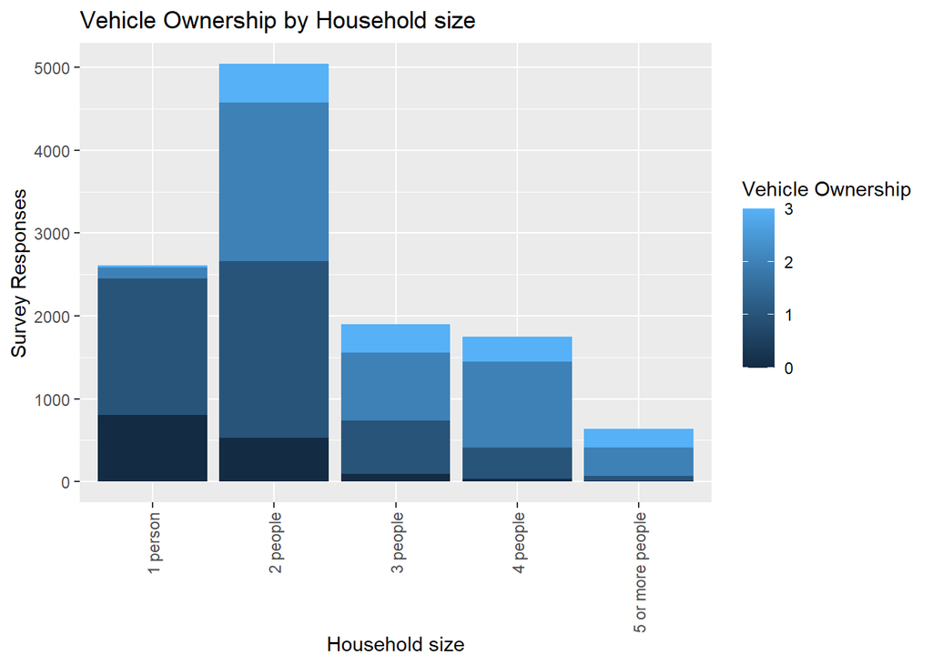

Reference group: 1 person

```
##                                  Value Std. Error   t value       p-value
## explanatory2 people          1.8622306 0.05089613  36.58884 4.303374e-293
## explanatory3 people          2.5612000 0.06323513  40.50280  0.000000e+00
## explanatory4 people          3.0042633 0.06444897  46.61461  0.000000e+00
## explanatory5 or more people  3.8025277 0.08962539  42.42690  0.000000e+00
## 0|1                         -0.6226809 0.03782205 -16.46344  6.717457e-61
## 1|2                          2.0218111 0.04591465  44.03412  0.000000e+00
## 2|3                          4.2846616 0.05518971  77.63515  0.000000e+00
##                             simp p-value
## explanatory2 people                    0
## explanatory3 people                    0
## explanatory4 people                    0
## explanatory5 or more people            0
## 0|1                                    0
## 1|2                                    0
## 2|3                                    0
```

**Vehicle Ownership by Household size**

|  | *Dependent variable:* |
| --- | --- |
|  | outcome |
| explanatory2 people | 1.862*** |
|  | (0.051) |
| explanatory3 people | 2.561*** |
|  | (0.063) |
| explanatory4 people | 3.004*** |
|  | (0.064) |
| explanatory5 or more people | 3.803*** |
|  | (0.090) |
| Observations | 11,940 |
| *Note:* | <sup>⋆</sup>p<0.1; <sup>⋆⋆</sup>p<0.05; <sup>⋆⋆⋆</sup>p<0.01 |

#### *5. License*

There are two ways to approach the topic of licenses, one at an individual-level and one at the household-level

- License status
- Number of household licenses

##### *5a. License Status*

The survey question provides respondents with 4 options for license status.

Original Data

```
##
##                              Missing: Skip logic
##                                              747
##            No, does not have a license or permit
##                                              778
##                      Yes, has a learner’s permit
##                                              120
## Yes, has an intermediate or unrestricted license
##                                             9519
```

These categories have been simplified to drivers or non-drivers. Those with a permit are considered to be drivers as they are in the pursuit of a license. Despite this recategorization, there is a large disparity between these groups, with over 10 times as many people reporting that they have a license.

```
##
##     Driver    Missing Non-driver
##      10415        747        778
```

| license_simp | Percentage_0 | Percentage_1 | Percentage_2 | Percentage_3 | Total_0 | Total_1 | Total_2 | Total_3 | Count_0 | Count_1 | Count_2 | Count_3 | sample_size | MOE_Percent |
| --- | --- | --- | --- | --- | --- | --- | --- | --- | --- | --- | --- | --- | --- | --- |
| Driver | 2.7925856 | 20.57662 | 44.62441 | 32.00638 | 94815.228 | 698627.50 | 1515109.84 | 1086696.24 | 1030 | 4411 | 3752 | 1222 | 10415 | 0.8059466 |
| Missing | 0.5635339 | 12.87769 | 54.91528 | 31.64350 | 2447.171 | 55921.94 | 238472.08 | 137413.34 | 13 | 205 | 411 | 118 | 747 | 3.0093701 |
| Non-driver | 41.3004560 | 31.37096 | 12.32721 | 15.00137 | 91718.762 | 69667.65 | 27375.89 | 33314.58 | 430 | 239 | 76 | 33 | 778 | 2.9488054 |

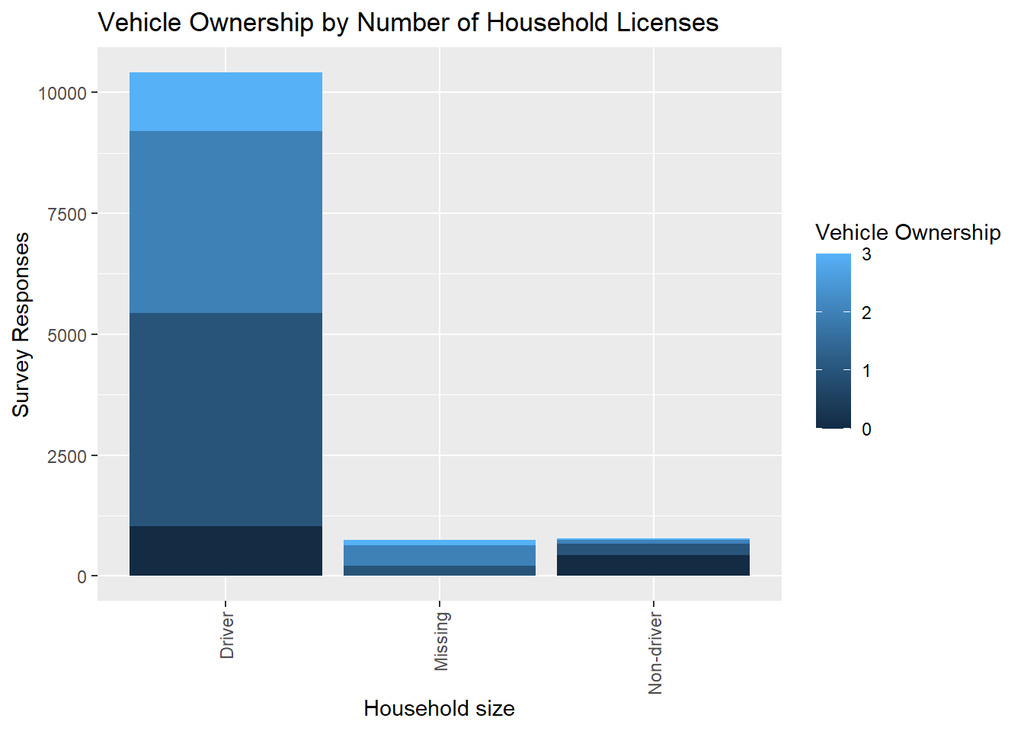

Reference group: Driver

```
##                             Value Std. Error    t value       p-value
## explanatoryMissing     0.77323306 0.06774560  11.413775  3.568985e-30
## explanatoryNon-driver -2.27786182 0.07726366 -29.481672 4.945830e-191
## 0|1                   -2.18674042 0.03145551 -69.518525  0.000000e+00
## 1|2                    0.07702691 0.01947762   3.954637  7.665078e-05
## 2|3                    2.04689060 0.02975018  68.802618  0.000000e+00
##                       simp p-value
## explanatoryMissing           0e+00
## explanatoryNon-driver        0e+00
## 0|1                          0e+00
## 1|2                          1e-04
## 2|3                          0e+00
```

**Vehicle Ownership by License Status**

|  | *Dependent variable:* |
| --- | --- |
|  | outcome |
| explanatoryMissing | 0.773*** |
|  | (0.068) |
| explanatoryNon-driver | -2.278*** |
|  | (0.077) |
| Observations | 11,940 |
| *Note:* | <sup>⋆</sup>p<0.1; <sup>⋆⋆</sup>p<0.05; <sup>⋆⋆⋆</sup>p<0.01 |

In reference to the individuals with licenses or in the process of attaining their licenses, those without are more likely to be part of households that own fewer vehicles. This association between license status and vehicle ownership is statistically significant.

##### *5b. Number of household licenses*

In addition to understanding the relationship between personal license status and vehicle ownership, because the explanatory variable is at the household level, the predictor variable was aggregated to understand the number of license holders within each household. This was determined using the simplified categorization used above: drivers and non-drivers

```
## Frequencies
## hh_license$hh_driver
## Type: Numeric
##
##               Freq   % Valid   % Valid Cum.   % Total   % Total Cum.
## ----------- ------ --------- -------------- --------- --------------
##           0    289      4.57           4.57      4.57           4.57
##           1   2678     42.38          46.95     42.38          46.95
##           2   2654     42.00          88.95     42.00          88.95
##           3    421      6.66          95.62      6.66          95.62
##           4    236      3.73          99.35      3.73          99.35
##           5     30      0.47          99.83      0.47          99.83
##           6      7      0.11          99.94      0.11          99.94
##           7      3      0.05          99.98      0.05          99.98
##           9      1      0.02         100.00      0.02         100.00
##        <NA>      0                               0.00         100.00
##       Total   6319    100.00         100.00    100.00         100.00
```

Because there are so few households with more than 4 drivers, these categories have been simplified.

```
## Frequencies
## hh_license$driver_simp
## Type: Factor
##
##               Freq   % Valid   % Valid Cum.   % Total   % Total Cum.
## ----------- ------ --------- -------------- --------- --------------
##           0    289      4.57           4.57      4.57           4.57
##           1   2678     42.38          46.95     42.38          46.95
##           2   2654     42.00          88.95     42.00          88.95
##           3    421      6.66          95.62      6.66          95.62
##           4    277      4.38         100.00      4.38         100.00
##        <NA>      0                               0.00         100.00
##       Total   6319    100.00         100.00    100.00         100.00
```

| driver_simp | Percentage_0 | Percentage_1 | Percentage_2 | Percentage_3 | Total_0 | Total_1 | Total_2 | Total_3 | Count_0 | Count_1 | Count_2 | Count_3 | sample_size | MOE_Percent |
| --- | --- | --- | --- | --- | --- | --- | --- | --- | --- | --- | --- | --- | --- | --- |
| 0 | 99.7551630 | 0.1064739 | 0.138363 | NA | 74668.089 | 79.69718 | 103.5666 | NA | 284 | 4 | 1 | NA | 289 | 4.838235 |
| 1 | 11.4976694 | 76.6212141 | 10.735108 | 1.146008 | 66610.726 | 443898.19898 | 62192.8968 | 6639.297 | 645 | 1856 | 149 | 28 | 2678 | 1.589391 |
| 2 | 2.0803645 | 16.0783257 | 55.518324 | 26.322986 | 37926.564 | 293119.61718 | 1012139.5737 | 479887.257 | 164 | 1017 | 1186 | 287 | 2654 | 1.596561 |
| 3 | 0.8441389 | 7.6451877 | 34.287503 | 57.223171 | 6193.908 | 56096.91622 | 251586.1252 | 419877.644 | 15 | 108 | 179 | 119 | 421 | 4.008620 |
| 4 | 0.4261294 | 3.6907134 | 54.122914 | 41.760243 | 3581.874 | 31022.66583 | 454935.6459 | 351019.959 | 3 | 48 | 166 | 60 | 277 | 4.941924 |

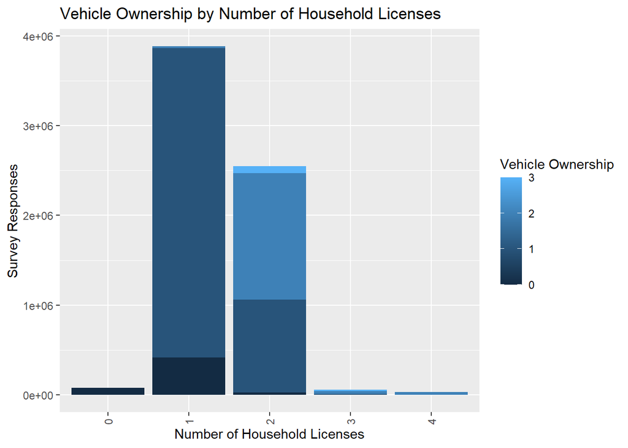

Reference group: 0 licenses in the household

```
##                 Value Std. Error   t value      p-value simp p-value
## explanatory1 5.052910  0.4530745 11.152494 6.962701e-29            0
## explanatory2 7.434571  0.4560955 16.300468 9.793950e-60            0
## explanatory3 8.356359  0.4652366 17.961526 3.899375e-72            0
## explanatory4 8.484637  0.4686819 18.103189 3.007419e-73            0
## 0|1          4.036753  0.4511479  8.947737 3.628446e-19            0
## 1|2          7.282680  0.4548819 16.010044 1.087327e-57            0
## 2|3          9.523917  0.4575101 20.816848 3.045753e-96            0
```

**Vehicle Ownership by Number of Household Licenses**

|  | *Dependent variable:* |
| --- | --- |
|  | outcome |
| explanatory1 | 5.053*** |
|  | (0.453) |
| explanatory2 | 7.435*** |
|  | (0.456) |
| explanatory3 | 8.356*** |
|  | (0.465) |
| explanatory4 | 8.485*** |
|  | (0.469) |
| Observations | 6,319 |
| *Note:* | <sup>⋆</sup>p<0.1; <sup>⋆⋆</sup>p<0.05; <sup>⋆⋆⋆</sup>p<0.01 |

In reference to the households with no licensed members, households with more licensed drivers are more likely to own more vehicles. This positive association between number of household licenses and household vehicle ownership is statistically significant.

#### *6. Number of workers*

Original Data

```
##
##    0    1    2    3    4    5
## 1727 4578 5052  472   87   24
```

```
##
##    1    2    3    4
## 1727 4578 5052  583
```

| numworkers_simp | Percentage_0 | Percentage_1 | Percentage_2 | Percentage_3 | Total_0 | Total_1 | Total_2 | Total_3 | Count_0 | Count_1 | Count_2 | Count_3 | sample_size | MOE_Percent |
| --- | --- | --- | --- | --- | --- | --- | --- | --- | --- | --- | --- | --- | --- | --- |
| 1 | 11.6467884 | 30.701134 | 40.97022 | 16.68185 | 65055.778 | 171488.15 | 228848.5 | 93180.27 | 378 | 735 | 459 | 155 | 1727 | 1.979200 |
| 2 | 5.9044047 | 32.831108 | 40.37702 | 20.88747 | 79462.940 | 441849.18 | 543403.9 | 281108.74 | 732 | 2321 | 1175 | 350 | 4578 | 1.215620 |
| 3 | 2.4944468 | 10.787966 | 54.17919 | 32.53840 | 40855.336 | 176690.87 | 887374.7 | 532930.66 | 349 | 1704 | 2386 | 613 | 5052 | 1.157189 |
| 4 | 0.7082048 | 6.712509 | 23.82158 | 68.75770 | 3607.108 | 34188.91 | 121330.8 | 350204.49 | 14 | 95 | 219 | 255 | 583 | 3.406447 |

[figure not shown]

```
##                    Value Std. Error    t value       p-value simp p-value
## explanatory2  0.06183653 0.05401459   1.144812  2.522871e-01       0.2523
## explanatory3  1.00253978 0.05381134  18.630643  1.813326e-77       0.0000
## explanatory4  2.41319731 0.09472842  25.474902 3.740922e-143       0.0000
## 0|1          -1.52091733 0.05006408 -30.379413 1.027568e-202       0.0000
## 1|2           0.68840806 0.04763304  14.452324  2.423678e-47       0.0000
## 2|3           2.76630798 0.05469410  50.577817  0.000000e+00       0.0000
```

**Vehicle Ownership by Number of Workers**

|  | *Dependent variable:* |
| --- | --- |
|  | outcome |
| explanatory2 | 0.062 |
|  | (0.054) |
| explanatory3 | 1.003*** |
|  | (0.054) |
| explanatory4 | 2.413*** |
|  | (0.095) |
| Observations | 11,940 |
| *Note:* | <sup>⋆</sup>p<0.1; <sup>⋆⋆</sup>p<0.05; <sup>⋆⋆⋆</sup>p<0.01 |

#### *7. Employment*

```
##
##           Employed full time (35+ hours/week, paid)
##                                                5892
## Employed part time (fewer than 35 hours/week, paid)
##                                                 867
##                                           Homemaker
##                                                 445
##                                 Missing: Skip logic
##                                                 801
##                              Not currently employed
##                                                 746
##                                             Retired
##                                                1567
##                                       Self-employed
##                                                 689
##                          Unpaid volunteer or intern
##                                                  84
```

Reference group: Employed full time (35+ hours/week, paid)

```
##                                                                      Value
## explanatoryEmployed part time (fewer than 35 hours/week, paid)  0.06697916
## explanatoryHomemaker                                            0.53387672
## explanatoryMissing: Skip logic                                  1.00726545
## explanatoryNot currently employed                              -0.61064273
## explanatoryRetired                                              0.19952559
## explanatorySelf-employed                                        0.14531818
## explanatoryUnpaid volunteer or intern                          -0.75448723
## 0|1                                                            -1.83758896
## 1|2                                                             0.29207337
## 2|3                                                             2.20481879
##                                                                Std. Error
## explanatoryEmployed part time (fewer than 35 hours/week, paid) 0.06855106
## explanatoryHomemaker                                           0.08906203
## explanatoryMissing: Skip logic                                 0.06742477
## explanatoryNot currently employed                              0.07534887
## explanatoryRetired                                             0.05311033
## explanatorySelf-employed                                       0.07470100
## explanatoryUnpaid volunteer or intern                          0.20920509
## 0|1                                                            0.03245432
## 1|2                                                            0.02513992
## 2|3                                                            0.03516565
##                                                                    t value
## explanatoryEmployed part time (fewer than 35 hours/week, paid)   0.9770696
## explanatoryHomemaker                                             5.9944369
## explanatoryMissing: Skip logic                                  14.9391015
## explanatoryNot currently employed                               -8.1042057
## explanatoryRetired                                               3.7568130
## explanatorySelf-employed                                         1.9453311
## explanatoryUnpaid volunteer or intern                           -3.6064478
## 0|1                                                            -56.6207893
## 1|2                                                             11.6179136
## 2|3                                                             62.6980883
##                                                                     p-value
## explanatoryEmployed part time (fewer than 35 hours/week, paid) 3.285347e-01
## explanatoryHomemaker                                           2.041917e-09
## explanatoryMissing: Skip logic                                 1.834317e-50
## explanatoryNot currently employed                              5.309120e-16
## explanatoryRetired                                             1.720910e-04
## explanatorySelf-employed                                       5.173514e-02
## explanatoryUnpaid volunteer or intern                          3.104173e-04
## 0|1                                                            0.000000e+00
## 1|2                                                            3.341980e-31
## 2|3                                                            0.000000e+00
##                                                                simp p-value
## explanatoryEmployed part time (fewer than 35 hours/week, paid)       0.3285
## explanatoryHomemaker                                                 0.0000
## explanatoryMissing: Skip logic                                       0.0000
## explanatoryNot currently employed                                    0.0000
## explanatoryRetired                                                   0.0002
## explanatorySelf-employed                                             0.0517
## explanatoryUnpaid volunteer or intern                                0.0003
## 0|1                                                                  0.0000
## 1|2                                                                  0.0000
## 2|3                                                                  0.0000
```

**Vehicle Ownership by Employment**

|  | *Dependent variable:* |
| --- | --- |
|  | outcome |
| explanatoryEmployed part time (fewer than 35 hours/week, paid) | 0.067 |
|  | (0.069) |
| explanatoryHomemaker | 0.534*** |
|  | (0.089) |
| explanatoryMissing: Skip logic | 1.007*** |
|  | (0.067) |
| explanatoryNot currently employed | -0.611*** |
|  | (0.075) |
| explanatoryRetired | 0.200*** |
|  | (0.053) |
| explanatorySelf-employed | 0.145* |
|  | (0.075) |
| explanatoryUnpaid volunteer or intern | -0.754*** |
|  | (0.209) |
| Observations | 11,091 |
| *Note:* | <sup>⋆</sup>p<0.1; <sup>⋆⋆</sup>p<0.05; <sup>⋆⋆⋆</sup>p<0.01 |

#### *8. Educational attainment*

```
##
##             Associates degree               Bachelor degree
##                           606                          4182
## Graduate/post-graduate degree          High school graduate
##                          3312                           642
##         Less than high school           Missing: Skip logic
##                           126                           801
##                  Some college Vocational/technical training
##                          1154                           268
```

Reference group: Associates degree

```
##                                                Value Std. Error     t value
## explanatoryBachelor degree               -0.48367903 0.08248051  -5.8641615
## explanatoryGraduate/post-graduate degree -0.40193724 0.08353986  -4.8113229
## explanatoryHigh school graduate          -0.03928710 0.10903966  -0.3603010
## explanatoryLess than high school         -0.06408896 0.19057197  -0.3362979
## explanatoryMissing: Skip logic            0.61481602 0.09949818   6.1791683
## explanatorySome college                  -0.34919633 0.09600578  -3.6372426
## explanatoryVocational/technical training  0.26306739 0.13934192   1.8879271
## 0|1                                      -2.21663275 0.08100188 -27.3652006
## 1|2                                      -0.10192064 0.07773306  -1.3111621
## 2|3                                       1.81293524 0.08058581  22.4969535
##                                                p-value simp p-value
## explanatoryBachelor degree                4.514079e-09       0.0000
## explanatoryGraduate/post-graduate degree  1.499346e-06       0.0000
## explanatoryHigh school graduate           7.186221e-01       0.7186
## explanatoryLess than high school          7.366462e-01       0.7366
## explanatoryMissing: Skip logic            6.444019e-10       0.0000
## explanatorySome college                   2.755723e-04       0.0003
## explanatoryVocational/technical training  5.903574e-02       0.0590
## 0|1                                      7.120970e-165       0.0000
## 1|2                                       1.898030e-01       0.1898
## 2|3                                      4.445692e-112       0.0000
```

**Vehicle Ownership by Education**

|  | *Dependent variable:* |
| --- | --- |
|  | outcome |
| explanatoryBachelor degree | -0.484*** |
|  | (0.082) |
| explanatoryGraduate/post-graduate degree | -0.402*** |
|  | (0.084) |
| explanatoryHigh school graduate | -0.039 |
|  | (0.109) |
| explanatoryLess than high school | -0.064 |
|  | (0.191) |
| explanatoryMissing: Skip logic | 0.615*** |
|  | (0.099) |
| explanatorySome college | -0.349*** |
|  | (0.096) |
| explanatoryVocational/technical training | 0.263* |
|  | (0.139) |
| Observations | 11,091 |
| *Note:* | <sup>⋆</sup>p<0.1; <sup>⋆⋆</sup>p<0.05; <sup>⋆⋆⋆</sup>p<0.01 |

#### *9. Race*

```
##
## African American            Asian         Hispanic          Missing
##              352             2141              583              877
##            Other       White Only
##              840             7147
```

Because of the small numbers of respondents identifying as non-white, these groups have been grouped together as “POC”. The “Missing/Other” group includes households categorized as “Missing” or “Other.”

```
##
##      White Only People of Color   Missing/Other
##            7147            3076            1717
```

| hh_race_2 | Percentage_0 | Percentage_1 | Percentage_2 | Percentage_3 | Total_0 | Total_1 | Total_2 | Total_3 | Count_0 | Count_1 | Count_2 | Count_3 | sample_size | MOE_Percent |
| --- | --- | --- | --- | --- | --- | --- | --- | --- | --- | --- | --- | --- | --- | --- |
| Missing/Other | 3.674802 | 24.98223 | 41.95219 | 29.39077 | 40379.57 | 274510.6 | 460980.4 | 322952.6 | 227 | 666 | 596 | 228 | 1717 | 1.984955 |
| People of Color | 8.149025 | 27.62114 | 42.57887 | 21.65097 | 78078.66 | 264647.8 | 407963.1 | 207445.5 | 424 | 1315 | 1052 | 285 | 3076 | 1.483005 |
| White Only | 3.535653 | 14.29137 | 45.72367 | 36.44931 | 70522.93 | 285058.7 | 912014.3 | 727026.1 | 822 | 2874 | 2591 | 860 | 7147 | 0.972913 |

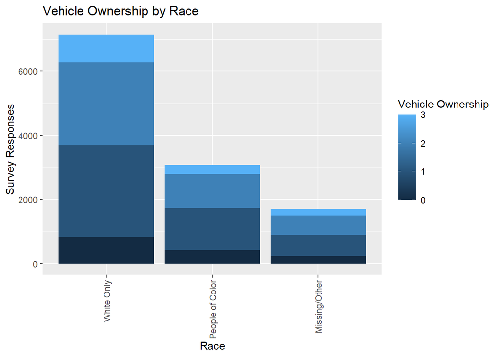

Reference group: White Only

```
##                                  Value Std. Error     t value      p-value
## explanatoryPeople of Color -0.20872355 0.03966759  -5.2618151 1.426402e-07
## explanatoryMissing/Other   -0.01766379 0.04994619  -0.3536563 7.235965e-01
## 0|1                        -2.02046910 0.03135590 -64.4366423 0.000000e+00
## 1|2                         0.06360362 0.02290329   2.7770517 5.485446e-03
## 2|3                         1.98710403 0.03158652  62.9098754 0.000000e+00
##                            simp p-value
## explanatoryPeople of Color       0.0000
## explanatoryMissing/Other         0.7236
## 0|1                              0.0000
## 1|2                              0.0055
## 2|3                              0.0000
```

**Vehicle Ownership by Race**

|  | *Dependent variable:* |
| --- | --- |
|  | outcome |
| explanatoryPeople of Color | -0.209*** |
|  | (0.040) |
| explanatoryMissing/Other | -0.018 |
|  | (0.050) |
| Observations | 11,940 |
| *Note:* | <sup>⋆</sup>p<0.1; <sup>⋆⋆</sup>p<0.05; <sup>⋆⋆⋆</sup>p<0.01 |

The relationship between race and household vehicle ownership is statistically significant with POC households owning fewer vehicles.

An alternative way to categorize race: White only (7,147), Asian (2,141), other POC (935), and missing/other (1,717).

| hh_race_3 | Percentage_0 | Percentage_1 | Percentage_2 | Percentage_3 | Total_0 | Total_1 | Total_2 | Total_3 | Count_0 | Count_1 | Count_2 | Count_3 | sample_size | MOE_Percent |
| --- | --- | --- | --- | --- | --- | --- | --- | --- | --- | --- | --- | --- | --- | --- |
| Asian | 5.200613 | 25.07438 | 50.01443 | 19.71057 | 25052.41 | 120788.4 | 240929.7 | 94949.85 | 276 | 933 | 754 | 178 | 2141 | 1.777574 |
| Missing/Other | 3.674802 | 24.98223 | 41.95219 | 29.39077 | 40379.57 | 274510.6 | 460980.4 | 322952.57 | 227 | 666 | 596 | 228 | 1717 | 1.984955 |
| People of Color | 11.130273 | 30.19625 | 35.06050 | 23.61297 | 53026.25 | 143859.4 | 167033.4 | 112495.66 | 148 | 382 | 298 | 107 | 935 | 2.689863 |
| White Only | 3.535653 | 14.29137 | 45.72367 | 36.44931 | 70522.93 | 285058.7 | 912014.3 | 727026.08 | 822 | 2874 | 2591 | 860 | 7147 | 0.972913 |

Reference group: White Only

```
##                                  Value Std. Error     t value      p-value
## explanatoryPeople of Color -0.22036415 0.06494799  -3.3929327 6.914862e-04
## explanatoryAsian           -0.20389592 0.04504102  -4.5268941 5.985690e-06
## explanatoryMissing/Other   -0.01766821 0.04994624  -0.3537445 7.235304e-01
## 0|1                        -2.02048985 0.03135633 -64.4364206 0.000000e+00
## 1|2                         0.06361335 0.02290334   2.7774707 5.478378e-03
## 2|3                         1.98709390 0.03158643  62.9097369 0.000000e+00
##                            simp p-value
## explanatoryPeople of Color       0.0007
## explanatoryAsian                 0.0000
## explanatoryMissing/Other         0.7235
## 0|1                              0.0000
## 1|2                              0.0055
## 2|3                              0.0000
```

**Vehicle Ownership by Race**

|  | *Dependent variable:* |
| --- | --- |
|  | outcome |
| explanatoryPeople of Color | -0.220*** |
|  | (0.065) |
| explanatoryAsian | -0.204*** |
|  | (0.045) |
| explanatoryMissing/Other | -0.018 |
|  | (0.050) |
| Observations | 11,940 |
| *Note:* | <sup>⋆</sup>p<0.1; <sup>⋆⋆</sup>p<0.05; <sup>⋆⋆⋆</sup>p<0.01 |

The relationship between race and household vehicle ownership is statistically significant with Asian and other POC households owning fewer vehicles.

#### *10. Housing*

This category can be analyzed at two different levels:

- housing tenure (rent vs. own)
- residential type

##### *10a. Housing tenure*

```
##
##                       Other         Own/paying mortgage
##                         122                        6436
##        Prefer not to answer Provided by job or military
##                         155                          41
##                        Rent
##                        5186
```

Because the majority of respondents identify as renters or owners, the other categories with fewer responses were grouped together.

```
##
## Own/paying mortgage                Rent               Other
##                6436                5186                 318
```

| rent_own_simp | Percentage_0 | Percentage_1 | Percentage_2 | Percentage_3 | Total_0 | Total_1 | Total_2 | Total_3 | Count_0 | Count_1 | Count_2 | Count_3 | sample_size | MOE_Percent |
| --- | --- | --- | --- | --- | --- | --- | --- | --- | --- | --- | --- | --- | --- | --- |
| Other | 6.5826692 | 25.41381 | 56.47533 | 11.52819 | 12725.75 | 49130.47 | 109179.2 | 22286.53 | 45 | 110 | 129 | 34 | 318 | 4.612351 |
| Own/paying mortgage | 0.5928816 | 12.56459 | 46.91161 | 39.93092 | 16471.58 | 349072.48 | 1303310.2 | 1109371.01 | 198 | 2076 | 2997 | 1165 | 6436 | 1.025246 |
| Rent | 14.7943467 | 39.44455 | 34.11640 | 11.64470 | 159783.83 | 426014.15 | 368468.4 | 125766.62 | 1230 | 2669 | 1113 | 174 | 5186 | 1.142141 |

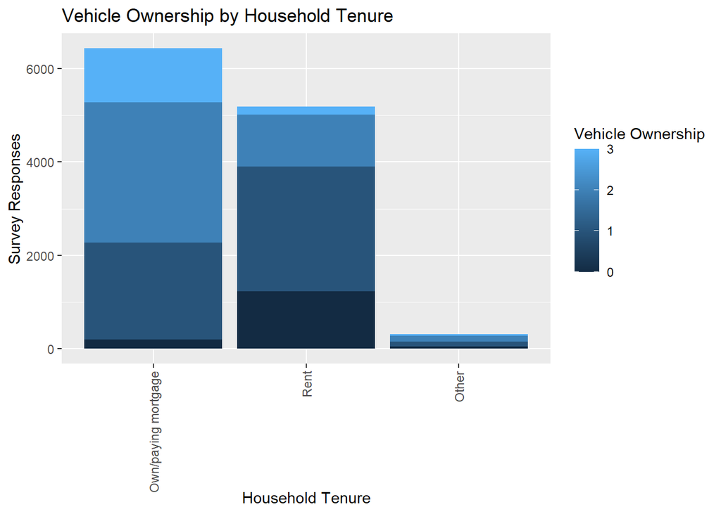

Reference group: Own/paying mortgage

```
##                       Value Std. Error    t value       p-value simp p-value
## explanatoryRent  -1.8120590 0.03883282 -46.663084  0.000000e+00            0
## explanatoryOther -0.7014794 0.11011545  -6.370399  1.885371e-10            0
## 0|1              -3.0470470 0.03901870 -78.091970  0.000000e+00            0
## 1|2              -0.6347403 0.02531814 -25.070575 1.041642e-138            0
## 2|3               1.5124664 0.03072788  49.221309  0.000000e+00            0
```

**Vehicle Ownership by Household Tenure**

|  | *Dependent variable:* |
| --- | --- |
|  | outcome |
| explanatoryRent | -1.812*** |
|  | (0.039) |
| explanatoryOther | -0.701*** |
|  | (0.110) |
| Observations | 11,940 |
| *Note:* | <sup>⋆</sup>p<0.1; <sup>⋆⋆</sup>p<0.05; <sup>⋆⋆⋆</sup>p<0.01 |

The relationship between household tenure and household vehicle ownership is statistically significant, with renting individuals reporting that they are part of households that own fewer vehicles.

#### *11. Housing / work location*

#### *12. Commuting patterns*

#### *13. Transit accessibility*

#### *14. Proximity to services*

### b. Overview: univariate analysis results

The table below shows which explanatory variables were statistically significant when analyzed against household vehicle ownership. Significance: *p<0.1; ***p<0.05; ***p<0.01

Explanatory variables

Significance

Trend (higher household vehicle ownership)

1. Income

***

higher income

2. Gender

N/A

3. Age/Household Lifecycle

***

households with children and older individuals

4. Household size

***

larger households

5. Number of licensed (or licensed age) individuals

***

higher number of household licenses

6. Number of workers

***

higher number of workers

7. Employment

*employment*

*employment*

8. Educational Attainment

education

*education*

9. Race or ethnicity

***

white only households

10. Housing type

***

owning households

11. Housing or work location and proximity to transit

*final_home_rgcnum (h), seattle_home (h)*

*final_home_rgcnum (h), seattle_home (h)*

12. Commuting patterns

*commute_freq (p), commute_mode (p), commute_dur (p), telecommute_freq (p)*

*commute_freq (p), commute_mode (p), commute_dur (p), telecommute_freq (p)*

13. Transit accessibility

*transit score by block group (e)*

*transit score by block group (e)*

14. Housing proximity to services

*displacement risk index (e)*

*displacement risk index (e)*

The outcome variable will be vehicle ownership (*“vehicle_group”*: 0, 1, 2, 3+)  
*Reference variables*